# PhD Chapter 3 - RelativeSize

```r
## - (3) Retain only the connected ecosystems, discarding the controls (unconnected) - ##

ds_ecosystems_effect_size = ds_ecosystems_effect_size %>%
  filter(connection == "connected")
```

However, Hedge’s d because of how much it depends on the pooled spread of the treatment and control might be harder to interpret than the log response ratio. Therefore, even though the log response ratio might not be calculated for all the protist species, we also decide to calculate it as well. To calculate the log response ratio of the dominance of protist species I use here the package `SingleCaseES` (see [this link](https://cran.r-project.org/web/packages/SingleCaseES/vignettes/Using-SingleCaseES.html)). This package. The package provides the function `LRRi` which calculates effect sizes for a single study case. It also adjust for small sample sizes by default.

```r
## - Calculate the effect size (Log Response Ratio). - ##

# Initialise the effect size columns

for (variable in length(protist_species_dominance)) {
  ds_ecosystems_effect_size <- ds_ecosystems_effect_size %>%
    mutate(!!paste0(protist_species_dominance[variable], "_LRR") := NA,
           !!paste0(protist_species_dominance[variable], "_LRR_upper") := NA,
           !!paste0(protist_species_dominance[variable], "_LRR_lower") := NA)
}

row_n = 0

# For each treatment, time point, and variable calculate LRR and 95% CI

for (treatment in 1:nrow(ecosystem_treatments_and_controls)) {

  for (time_p in 0:(length(time_points)-1)) {

      for (variable in 1:length(protist_species_dominance)) {

        row_n = row_n + 1

        treatment_values = ds_ecosystems %>%
          filter(ecosystem_type == ecosystem_treatments_and_controls$treatment[treatment],
                 time_point == time_points[time_p+1],
                 !is.na(!!sym(protist_species_dominance[variable]))) %>%
          pull(!!sym(protist_species_dominance[variable]))

        control_values = ds_ecosystems %>%
          filter(ecosystem_type == ecosystem_treatments_and_controls$control[treatment],
                 time_point == time_points[time_p+1],
                 !is.na(!!sym(protist_species_dominance[variable]))) %>%
          pull(!!sym(protist_species_dominance[variable]))

        # By default it corrects for small sample sizes and calculates 95 % CI.

        LRR_output = LRRi(A_data = control_values,
                          B_data = treatment_values,
                          scale = "proportion")

        ds_ecosystems_effect_size[[paste0(protist_species_dominance[variable], "_LRR")]][
          ds_ecosystems_effect_size$ecosystem_type ==
           ecosystem_treatments_and_controls$treatment[treatment] &
          ds_ecosystems_effect_size$time_point ==
           time_points[time_p+1]] =
          LRR_output$Est

        ds_ecosystems_effect_size[[paste0(protist_species_dominance[variable], "_LRR_upper")]][
          ds_ecosystems_effect_size$ecosystem_type ==
           ecosystem_treatments_and_controls$treatment[treatment] &
          ds_ecosystems_effect_size$time_point ==
           time_points[time_p+1]] =
          LRR_output$CI_upper

        ds_ecosystems_effect_size[[paste0(protist_species_dominance[variable], "_LRR_lower")]][
          ds_ecosystems_effect_size$ecosystem_type ==
           ecosystem_treatments_and_controls$treatment[treatment] &
          ds_ecosystems_effect_size$time_point ==
           time_points[time_p+1]] =
          LRR_output$CI_lower

      }
    }
  }
```

[output not shown]

[output not shown]

[output cut: 10 more lines]

[output not shown]

[output not shown]

[output cut: 10 more lines]

[output not shown]

[output not shown]

[output not shown]

[output not shown]

[output not shown]

[output not shown]

[output not shown]

[output not shown]

### Meta-ecosystems (`ds_metaecosystems`)

To analyse the biomass within meta-ecosystems in our experiment, we require a dataset where each row represents a connected or unconnected meta-ecosystem at a specific time point (`ds_metaecosystems`). To do so, we need to identify which ecosystems to combine in unconnected & connected meta-ecosystems (storing combinations in `ecosystem_combinations)` and then sum the biomass of combined ecosystems (from `ds_ecosystems`) into `ds_metaecosytems` by going through the following steps. (1) Identify the combinations of ecosystems that constitute connected meta-ecosystems. This allows us to know the biomass of which ecosystems to sum. (2) Determine the ecosystem IDs of unconnected ecosystems. This allows us to then create unconnected meta-ecosystems. (3) Identify the combinations of ecosystems that constitute unconnected meta-ecosystems. This allows us to know the biomass of which ecosystems to sum. (4) Bind connected and unconnected meta-ecosystem combinations. (5) Create ds_metaecosystems.

```r
## - (1) Identify the combinations of ecosystems that constitute connected meta-ecosystems. - ##

combinations_connected = ds_ecosystems %>%

  # To have the information about to which system nr and metaecosystem type each ecosystem belongs, we select one of the time points to don't have multiple informations of the same ecosystem.

  filter(time_point == 0,

         # To create only combinations for connected metaecosystems, we filter the combinations of only connected ecosystems

         connection == "connected") %>%
  select(system_nr,
         metaecosystem_type,
         ecosystem_ID) %>%

    # To know which ecosystems were combined to for the connected meta-ecosystem, assign the ecosystem ID to the first and second ecosystems as mean ± 0.5. This is because the two ecosystems of a meta-ecosystem are two integers next to each other (e.g., 31 and 32).

  group_by(system_nr,
           metaecosystem_type) %>%
  summarise(ID_first_ecosystem = (mean(ecosystem_ID) - 0.5),
            ID_second_ecosystem = (mean(ecosystem_ID) + 0.5)) %>%
  as.data.frame()
```

```r
## - (2) Determine the ecosystem IDs of unconnected ecosystems. - ##

# Autotrophic

ID_unconnected_small_autotrophic_s = ds_ecosystems %>%
  filter(ecosystem_type == "S-A unconnected (s)") %>%
  pull(ecosystem_ID) %>%
  unique()

ID_unconnected_small_medium_autotrophic_s = ds_ecosystems %>%
  filter(ecosystem_type == "SM-A unconnected (s)") %>%
  pull(ecosystem_ID) %>%
  unique()

ID_unconnected_medium_large_autotrophic_s = ds_ecosystems %>%
  filter(ecosystem_type == "ML-A unconnected (s)") %>%
  pull(ecosystem_ID) %>%
  unique()

ID_unconnected_large_autotrophic_s = ds_ecosystems %>%
  filter(ecosystem_type == "L-A unconnected (s)") %>%
  pull(ecosystem_ID) %>%
  unique()

ID_unconnected_small_autotrophic_sd = ds_ecosystems %>%
  filter(ecosystem_type == "S-A unconnected (s*d)") %>%
  pull(ecosystem_ID) %>%
  unique()

ID_unconnected_small_medium_autotrophic_sd = ds_ecosystems %>%
  filter(ecosystem_type == "SM-A unconnected (s*d)") %>%
  pull(ecosystem_ID) %>%
  unique()

ID_unconnected_medium_large_autotrophic_sd = ds_ecosystems %>%
  filter(ecosystem_type == "ML-A unconnected (s*d)") %>%
  pull(ecosystem_ID) %>%
  unique()

ID_unconnected_large_autotrophic_sd = ds_ecosystems %>%
  filter(ecosystem_type == "L-A unconnected (s*d)") %>%
  pull(ecosystem_ID) %>%
  unique()


# Heterotrophic

ID_unconnected_small_heterotrophic_s = ds_ecosystems %>%
  filter(ecosystem_type == "S-H unconnected (s)") %>%
  pull(ecosystem_ID) %>%
  unique()

ID_unconnected_small_medium_heterotrophic_s = ds_ecosystems %>%
  filter(ecosystem_type == "SM-H unconnected (s)") %>%
  pull(ecosystem_ID) %>%
  unique()

ID_unconnected_medium_large_heterotrophic_s = ds_ecosystems %>%
  filter(ecosystem_type == "ML-H unconnected (s)") %>%
  pull(ecosystem_ID) %>%
  unique()

ID_unconnected_large_heterotrophic_s = ds_ecosystems %>%
  filter(ecosystem_type == "L-H unconnected (s)") %>%
  pull(ecosystem_ID) %>%
  unique()

ID_unconnected_small_heterotrophic_sd = ds_ecosystems %>%
  filter(ecosystem_type == "S-H unconnected (s*d)") %>%
  pull(ecosystem_ID) %>%
  unique()

ID_unconnected_small_medium_heterotrophic_sd = ds_ecosystems %>%
  filter(ecosystem_type == "SM-H unconnected (s*d)") %>%
  pull(ecosystem_ID) %>%
  unique()

ID_unconnected_medium_large_heterotrophic_sd = ds_ecosystems %>%
  filter(ecosystem_type == "ML-H unconnected (s*d)") %>%
  pull(ecosystem_ID) %>%
  unique()

ID_unconnected_large_heterotrophic_sd = ds_ecosystems %>%
  filter(ecosystem_type == "L-H unconnected (s*d)") %>%
  pull(ecosystem_ID) %>%
  unique()
```

```r
## - (3) Identify the combinations of ecosystems that constitute unconnected meta-ecosystems. - ##

combinations_small_s = crossing(ID_unconnected_small_autotrophic_s,
                                ID_unconnected_small_heterotrophic_s) %>%
  mutate(metaecosystem_type = "S unconnected (s)") %>%
  rename(ID_first_ecosystem = ID_unconnected_small_autotrophic_s,
         ID_second_ecosystem = ID_unconnected_small_heterotrophic_s) %>%
  select(metaecosystem_type,
         ID_first_ecosystem,
         ID_second_ecosystem)

combinations_small_medium_s = crossing(ID_unconnected_small_medium_autotrophic_s,
                                       ID_unconnected_small_medium_heterotrophic_s) %>%
  mutate(metaecosystem_type = "SM unconnected (s)") %>%
  rename(ID_first_ecosystem = ID_unconnected_small_medium_autotrophic_s,
         ID_second_ecosystem = ID_unconnected_small_medium_heterotrophic_s) %>%
  select(metaecosystem_type,
         ID_first_ecosystem,
         ID_second_ecosystem)

combinations_medium_large_s = crossing(ID_unconnected_medium_large_autotrophic_s,
                                ID_unconnected_medium_large_heterotrophic_s) %>%
  mutate(metaecosystem_type = "ML unconnected (s)") %>%
  rename(ID_first_ecosystem = ID_unconnected_medium_large_autotrophic_s,
         ID_second_ecosystem = ID_unconnected_medium_large_heterotrophic_s) %>%
  select(metaecosystem_type,
         ID_first_ecosystem,
         ID_second_ecosystem)

combinations_large_s = crossing(ID_unconnected_large_autotrophic_s,
                                ID_unconnected_large_heterotrophic_s) %>%
  mutate(metaecosystem_type = "L unconnected (s)") %>%
  rename(ID_first_ecosystem = ID_unconnected_large_autotrophic_s,
         ID_second_ecosystem = ID_unconnected_large_heterotrophic_s) %>%
  select(metaecosystem_type,
         ID_first_ecosystem,
         ID_second_ecosystem)


combinations_small_sd = crossing(ID_unconnected_small_autotrophic_sd,
                                ID_unconnected_small_heterotrophic_sd) %>%
  mutate(metaecosystem_type = "S unconnected (s*d)") %>%
  rename(ID_first_ecosystem = ID_unconnected_small_autotrophic_sd,
         ID_second_ecosystem = ID_unconnected_small_heterotrophic_sd) %>%
  select(metaecosystem_type,
         ID_first_ecosystem,
         ID_second_ecosystem)

combinations_small_medium_sd = crossing(ID_unconnected_small_medium_autotrophic_sd,
                                       ID_unconnected_small_medium_heterotrophic_sd) %>%
  mutate(metaecosystem_type = "SM unconnected (s*d)") %>%
  rename(ID_first_ecosystem = ID_unconnected_small_medium_autotrophic_sd,
         ID_second_ecosystem = ID_unconnected_small_medium_heterotrophic_sd) %>%
  select(metaecosystem_type,
         ID_first_ecosystem,
         ID_second_ecosystem)

combinations_medium_large_sd = crossing(ID_unconnected_medium_large_autotrophic_sd,
                                ID_unconnected_medium_large_heterotrophic_sd) %>%
  mutate(metaecosystem_type = "ML unconnected (s*d)") %>%
  rename(ID_first_ecosystem = ID_unconnected_medium_large_autotrophic_sd,
         ID_second_ecosystem = ID_unconnected_medium_large_heterotrophic_sd) %>%
  select(metaecosystem_type,
         ID_first_ecosystem,
         ID_second_ecosystem)

combinations_large_sd = crossing(ID_unconnected_large_autotrophic_sd,
                                ID_unconnected_large_heterotrophic_sd) %>%
  mutate(metaecosystem_type = "L unconnected (s*d)") %>%
  rename(ID_first_ecosystem = ID_unconnected_large_autotrophic_sd,
         ID_second_ecosystem = ID_unconnected_large_heterotrophic_sd) %>%
  select(metaecosystem_type,
         ID_first_ecosystem,
         ID_second_ecosystem)

combinations_unconnected = rbind(combinations_small_s,
                                 combinations_small_medium_s,
                                 combinations_medium_large_s,
                                 combinations_large_s,
                                 combinations_small_sd,
                                 combinations_small_medium_sd,
                                 combinations_medium_large_sd,
                                 combinations_large_sd) %>%

  # To have a system nr for all the unconnected meta-ecosystems, give them a nr that starts from 1000, so that they can be distinguished from the connected meta-ecosystems.

  mutate(system_nr = 1001:(1000 + nrow(.))) %>%
  select(system_nr,
         metaecosystem_type,
         ID_first_ecosystem,
         ID_second_ecosystem)
```

```r
## - (4) Bind connected and unconnected meta-ecosystem combinations. - ##

ecosystem_combinations = rbind(combinations_connected,
                               combinations_unconnected) %>%
  mutate(connection = ifelse(str_detect(metaecosystem_type, "unconnected"),
                             "unconnected",
                             "connected"),
         ecosystems_combined = paste0(ID_first_ecosystem, "|", ID_second_ecosystem))
```

```r
## - (5) Create ds_metaecosystems. - ##

row_i = 0
for (combination in 1 : nrow(ecosystem_combinations)) {
  for (time_p in time_points) {

    row_i = row_i + 1

    ds_metaecosystems[[ row_i]] = ds_ecosystems %>%
      filter(ecosystem_ID %in% c(ecosystem_combinations[combination, ]$ID_first_ecosystem,
                                 ecosystem_combinations[combination, ]$ID_second_ecosystem),
             time_point == time_p) %>%
      group_by(time_point,
               day,
               metaecosystem_type,
               ecosystem_size,
               connection,
               size_effects) %>%
      summarise(total_metaecosystem_bioarea_mm2 = sum(bioarea_tot_mm2)) %>%
      mutate(

             # To know on which day the meta-ecosystem was sampled, select the sampling day that is time_p + 1. This is because the first sampling day is at time point 0, so all the days are shifted of 1 on place (e.g., the sampling day of time point 1 is at sampling_days[2]).

             system_nr = ecosystem_combinations[combination, ]$system_nr,
             ecosystems_combined = ecosystem_combinations[combination, ]$ecosystems_combined) %>%
      rename(size = ecosystem_size) %>%
      ungroup()
  }
}

ds_metaecosystems = ds_metaecosystems %>%
  bind_rows() %>%
  as.data.frame() %>%
  filter(!system_nr %in% metaecosystems_to_take_off)
```

### Meta-ecosystems effect sizes (`ds_metaecos_es`)

Here I want to get the effect size of the meta-ecosystem biomass. I run this code on 2023.11.24. I should redo it as I would like in this case to use the log response ratio, as there is no zero in the total biomass (the lowest biomass in the experiment was 0.0148882.

```r
# I run this code on 2023.11.24
calculate.effect.sizes.metaecos = function() {

  for (metaeco_type in 1:length(treatments_and_controls_metaecos$treatment) {

    isolated_type_i = treatments_and_controls_metaecos %>%
            filter(treatment == metaeco_type_i) %>%
            pull(control)

    nr_of_sets = combination_sets_isolated_systems %>%
      filter(system_type == isolated_type_i) %>%
      pull(set) %>%
      max()

    for (set_i in 1 : nr_of_sets) {
      variable_count = 0
      for (variable_i in variables_metaecos) {
        variable_count = variable_count + 1
        for (time_point_i in time_points) {
          if(time_point_i == 0) next

          #Parameters
          columns_to_group_by = columns_metaecos[(columns_metaecos != "system_nr") & (columns_metaecos != "patches_combined")]

          system_nrs_of_set_i = combination_sets_isolated_systems %>%
            filter(system_type %in% isolated_type_i,
                   set == set_i) %>%
            pull(system_nr)

          new_dataset = ds_metaecosystems %>%
            filter(system_type == metaeco_type_i | system_nr %in% system_nrs_of_set_i,
                   time_point == time_point_i,
                   !is.na(!!sym(variable_i))) %>%
            group_by_at(all_of(columns_to_group_by)) %>%
            summarise(across(all_of(variable_i),
                             list(mean = mean,
                                  sd = sd)),
                      sample_size = n()) %>%
            rename_with(~ paste0(variable_i, "_sample_size"),
                        matches("sample_size")) %>%
            mutate(!!paste0(variable_i, "_d") := NA,
                   !!paste0(variable_i, "_d_upper") := NA,
                   !!paste0(variable_i, "_d_lower") := NA)

          treatment_row = new_dataset %>%
            filter(system_type == metaeco_type_i)

          control_row = new_dataset %>%
            filter(system_type == isolated_type_i)

          hedges_d = calculate.hedges_d(
            treatment_row[[paste0(variable_i, "_mean")]],
            treatment_row[[paste0(variable_i, "_sd")]],
            treatment_row[[paste0(variable_i, "_sample_size")]],
            control_row[[paste0(variable_i, "_mean")]],
            control_row[[paste0(variable_i, "_sd")]],
            control_row[[paste0(variable_i, "_sample_size")]]
          )

          new_row = new_dataset %>%
            filter(system_type == metaeco_type_i) %>%
            mutate(!!paste0(variable_i, "_d") := hedges_d$d,
                   !!paste0(variable_i, "_d_upper") := hedges_d$upper_CI,
                   !!paste0(variable_i, "_d_lower") := hedges_d$lower_CI)

          if (!exists("ds_metaecos_es")) {ds_metaecos_es = new_row} else
            {ds_metaecos_es = rbind(ds_metaecos_es, new_row)}

        }
      }
    }
  }

  ds_metaecos_es %>%
    group_by_at(all_of(columns_to_group_by)) %>%
    summarise(total_metaecosystem_bioarea_mm2_d = mean(total_metaecosystem_bioarea_mm2_d),
              total_metaecosystem_bioarea_mm2_d_upper = mean(total_metaecosystem_bioarea_mm2_d_upper),
              total_metaecosystem_bioarea_mm2_d_lower = mean(total_metaecosystem_bioarea_mm2_d_lower))

  return(ds_metaecos_es)

}
```

```r
ds_metaecos_es = read.csv(file = here("results", "calculations", "ds_metaecos_es.csv"))
```

## Plots & analysis

### Meta-ecosystems

```r
response_variable = "total_metaecosystem_bioarea_mm2"
```

#### Biomass

In the experiment we studied two-patch meta-ecosystems in which we manipulated the size of their patches and their connection (unconnected vs connected). Now, we want to know whether meta-ecosystem size influenced the effects of connection on this response variable. Therefore, we start by looking at how this response variable changed across time for all meta-ecosystems through its mean ± 95 confidence interval:

```r
print("Size effects")
```

```
## [1] "Size effects"
```

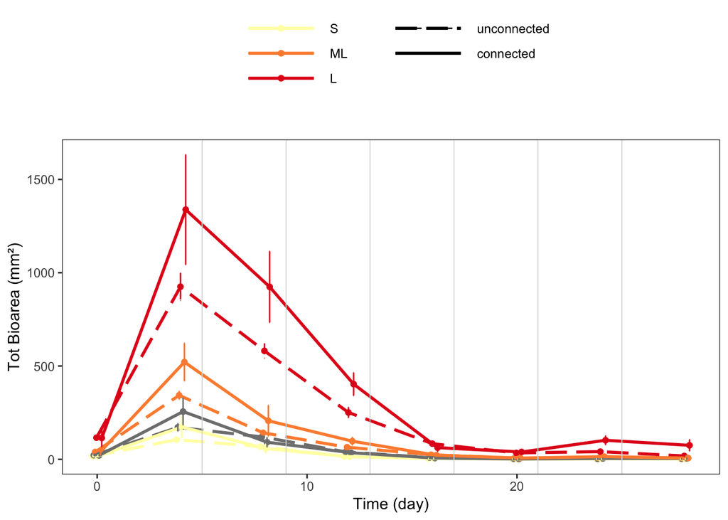

```r
plot.metaecos.points(ds_metaecosystems %>% filter(size_effects == "s"),
                      response_variable)
```

```r
print("Size * Disturbance effects")
```

```
## [1] "Size * Disturbance effects"
```

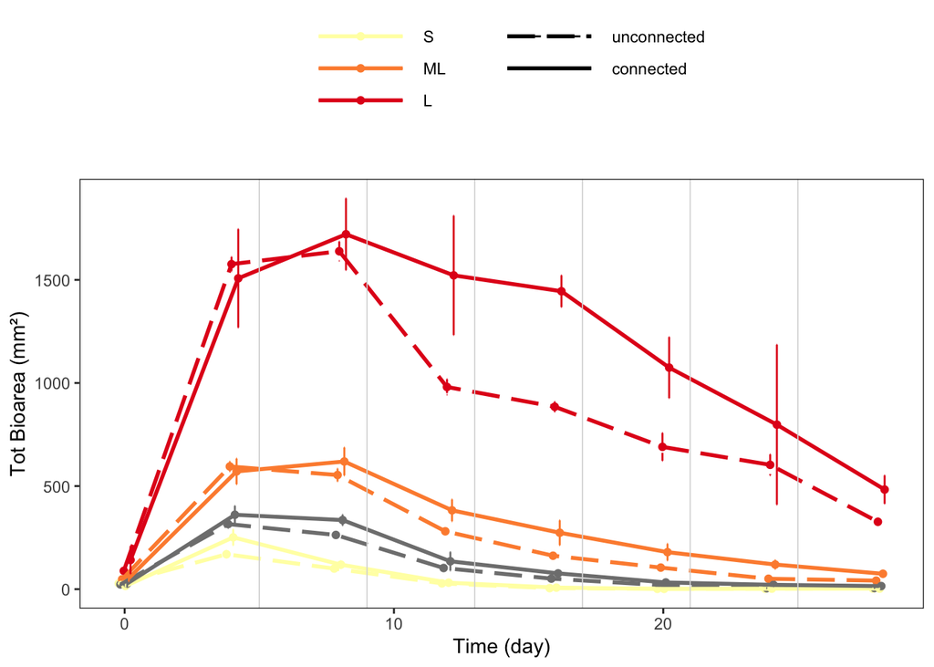

```r
plot.metaecos.points(ds_metaecosystems %>% filter(size_effects == "s*d"),
                      response_variable)
```

**Click here to view the same data represented through the single replicates**

```r
print("Size effects")
```

```
## [1] "Size effects"
```

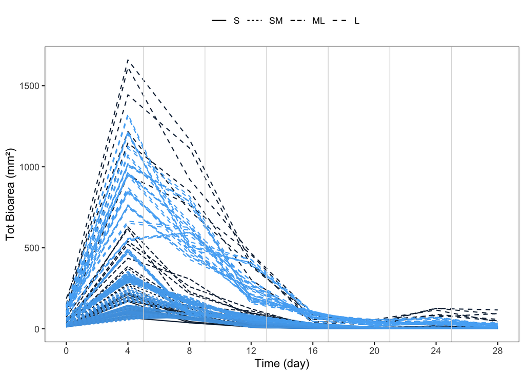

```r
plot.metaecos.replicates(ds_metaecosystems %>% filter(size_effects == "s"),
                         response_variable)
```

```r
print("Size * Disturbance effects")
```

```
## [1] "Size * Disturbance effects"
```

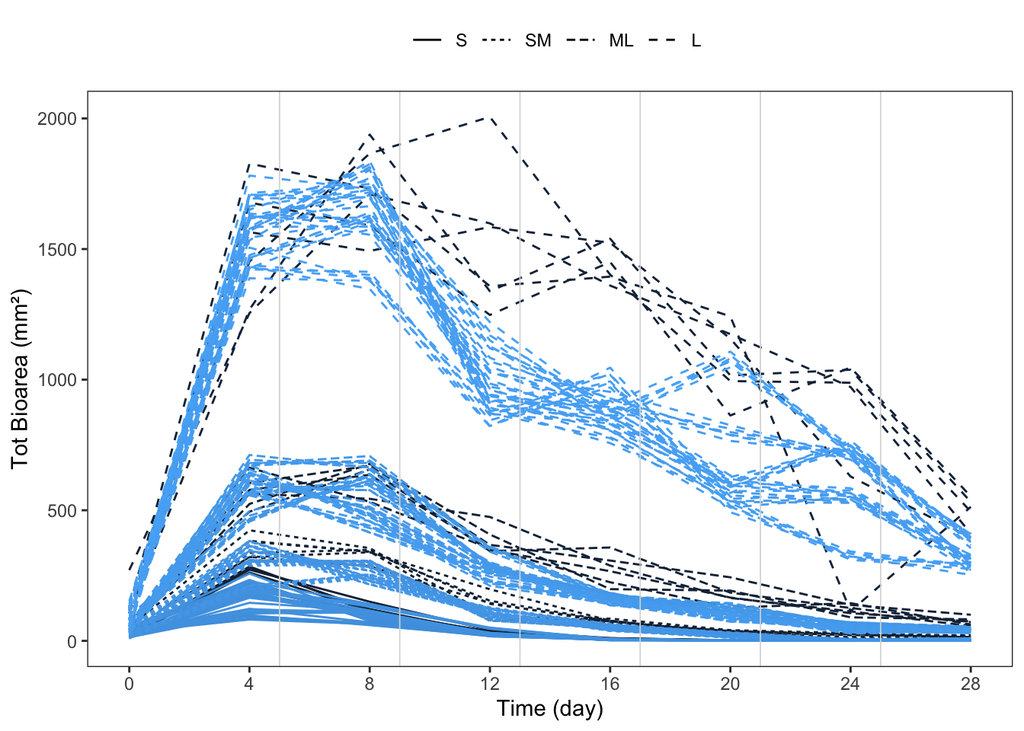

```r
plot.metaecos.replicates(ds_metaecosystems %>% filter(size_effects == "s*d"),
                         response_variable)
```

**Click here to view the same data represented through effect sizes**

**WORK IN PROGRESS**

Here I need to rerun this complicated code with the right ds_metaecosystems format.

```r
plot.metaecos.points.ES(ds_metaecos_es %>% filter(size_effects == size_effects_i),
                         metaecosystem_type_i[grep("meta-ecosystem", metaecosystem_type_i)],
                         paste0(response_variable, "_d"))
```

Following the initial inspection, we proceed to analyse statistical differences among meta-ecosystems. Our first step involves filtering the data to isolate the relevant data for analysis. Specifically, we exclude data points where the response variable couldn’t be computed, as well as time points preceding the initial disturbance and resource flow. Then we plot the data to make sure that data was filtered in the right way.

```r
filtered_data = ds_metaecosystems %>%
  filter(time_point >= first_time_point_model,
         time_point <= last_time_point_model,
         !is.na(!!sym(response_variable)),
         connection == "connected" |
          ecosystems_combined %in% unconnected_metaecosystems_selected)
```

```r
print("Size effects")
```

```
## [1] "Size effects"
```

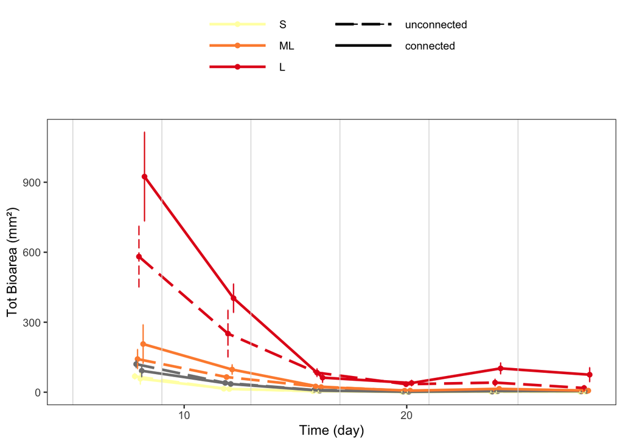

```r
plot.metaecos.points(filtered_data %>% filter(size_effects == "s"),
                     response_variable)
```

```r
print("Size * Disturbance effects")
```

```
## [1] "Size * Disturbance effects"
```

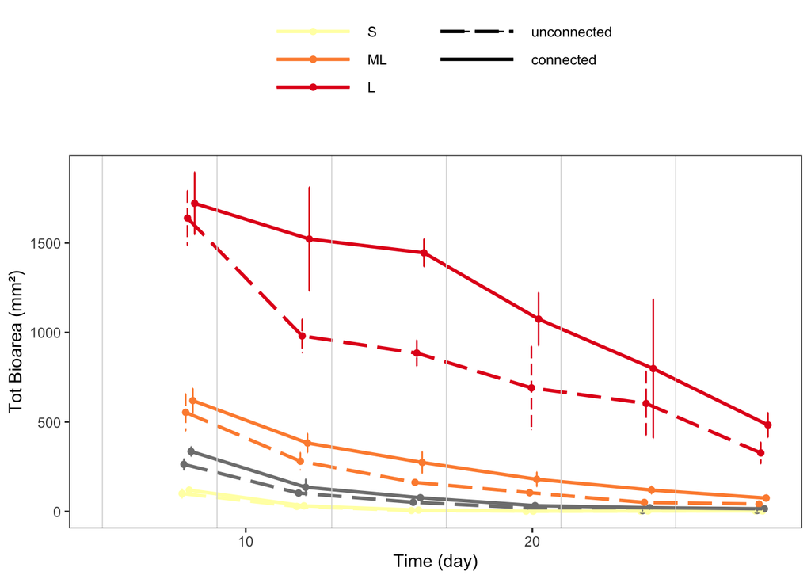

```r
plot.metaecos.points(filtered_data %>% filter(size_effects == "s*d"),
                     response_variable)
```

Then, to examine how the interaction between meta-ecosystem type size connectivity influenced the response variable, we develop a mixed effect model (`full_model`) with lmerTest (Kuznetsova et al., 2017), treating system nr and time as random effects  
(**Response variable ~ type * connection + (1 | system_nr) + (1 | day)**, see [this link](https://cran.r-project.org/web/packages/lme4/vignettes/lmer.pdf) for how to code). In this model we don’t use a Restricted Maximum Likelihood (REML) because, while REML is robust to missing data, it may not perform well with very small sample sizes, especially when the number of random effects is large relative to the number of observations (ChatGPT). After having created the model, we show (i) the significance of the predictor variables through the summary of the model and (ii) the model residuals.

Significance is tested by comparing their slope against zero using a t-test which employs the Satterthwaite’s method to estimate the degrees of freedom for the two groups (fixed variable slope and zero). This method is conservative in order to prevent false positives (Li & Redden, 2015). An alternative method that could be used is the Kenward-Roger’s method, however, it is expected to perform similarly. Because the model utilises Satterthwaite’s method, it should entail a Welch t-test (according to information gleaned from [this Wikipedia page](https://en.wikipedia.org/wiki/Welch%E2%80%93Satterthwaite_equation)), which does not assume equal variance in the two groups. There is no option in this package to alter the type of t-test.

```r
## - Create mixed effect model - ##

# In the ouput lmerModLmerTest which means that it's a Linear Mixed Model from the lmerTest package

model = lmer(
   get(response_variable) ~
     size * connection * size_effects +
     (1 | system_nr) +
     (1 | day),
   data = filtered_data,
   REML = FALSE,
   control = lmerControl(optimizer = "Nelder_Mead"))
```

```r
## - Show summary of the model -- ##

print(summary(model), digits = 3)
```

```
## Linear mixed model fit by maximum likelihood . t-tests use Satterthwaite's
##   method [lmerModLmerTest]
## Formula: get(response_variable) ~ size * connection * size_effects + (1 |
##     system_nr) + (1 | day)
##    Data: filtered_data
## Control: lmerControl(optimizer = "Nelder_Mead")
##
##      AIC      BIC   logLik deviance df.resid
##   7501.4   7584.2  -3731.7   7463.4      557
##
## Scaled residuals:
##    Min     1Q Median     3Q    Max
## -6.253 -0.366 -0.020  0.438  4.986
##
## Random effects:
##  Groups    Name        Variance Std.Dev.
##  system_nr (Intercept)     0      0
##  day       (Intercept) 17777    133
##  Residual              23736    154
## Number of obs: 576, groups:  system_nr, 96; day, 6
##
## Fixed effects:
##                                            Estimate Std. Error     df t value
## (Intercept)                                   15.65      60.18   8.72    0.26
## sizeSM                                        14.15      36.31 570.00    0.39
## sizeML                                        26.14      36.31 570.00    0.72
## sizeL                                        152.64      36.31 570.00    4.20
## connectionconnected                           -2.04      36.31 570.00   -0.06
## size_effectss*d                                7.59      36.31 570.00    0.21
## sizeSM:connectionconnected                    -3.50      51.36 570.00   -0.07
## sizeML:connectionconnected                    19.21      51.36 570.00    0.37
## sizeL:connectionconnected                    101.43      51.36 570.00    1.98
## sizeSM:size_effectss*d                        37.16      51.36 570.00    0.72
## sizeML:size_effectss*d                       149.49      51.36 570.00    2.91
## sizeL:size_effectss*d                        678.20      51.36 570.00   13.21
## connectionconnected:size_effectss*d            6.20      51.36 570.00    0.12
## sizeSM:connectionconnected:size_effectss*d    27.39      72.63 570.00    0.38
## sizeML:connectionconnected:size_effectss*d    52.60      72.63 570.00    0.72
## sizeL:connectionconnected:size_effectss*d    214.34      72.63 570.00    2.95
##                                            Pr(>|t|)
## (Intercept)                                  0.8008
## sizeSM                                       0.6969
## sizeML                                       0.4719
## sizeL                                       3.1e-05 ***
## connectionconnected                          0.9552
## size_effectss*d                              0.8345
## sizeSM:connectionconnected                   0.9456
## sizeML:connectionconnected                   0.7085
## sizeL:connectionconnected                    0.0487 *
## sizeSM:size_effectss*d                       0.4696
## sizeML:size_effectss*d                       0.0037 **
## sizeL:size_effectss*d                       < 2e-16 ***
## connectionconnected:size_effectss*d          0.9039
## sizeSM:connectionconnected:size_effectss*d   0.7062
## sizeML:connectionconnected:size_effectss*d   0.4692
## sizeL:connectionconnected:size_effectss*d    0.0033 **
## ---
## Signif. codes:  0 '***' 0.001 '**' 0.01 '*' 0.05 '.' 0.1 ' ' 1
## optimizer (Nelder_Mead) convergence code: 0 (OK)
## boundary (singular) fit: see help('isSingular')
```

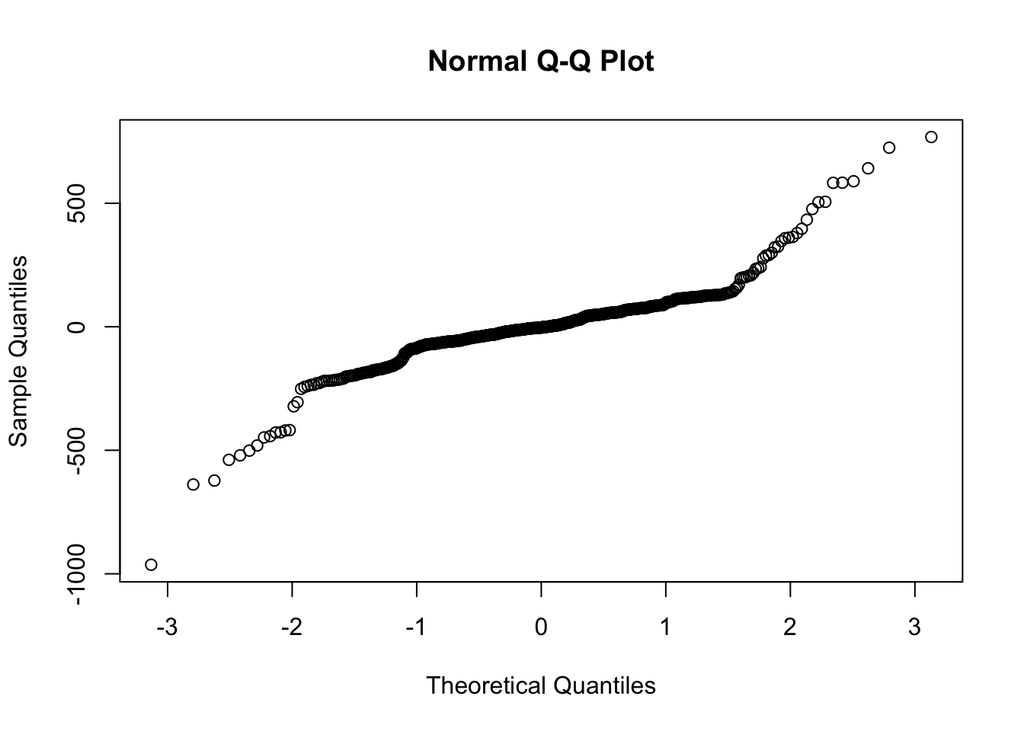

```r
## - Plot residuals of the model -- ##

qqnorm(resid(model))
```

```r
create.res.vs.fit.metaecos(model,
                           filtered_data)
```

[interactive chart not shown]

However, this model’s output complicates understanding the fixed effects. To enhance clarity in demonstrating the statistical significance of fixed effects, we employ a type III ANOVA on the full model. This method accommodates unbalanced designs and yields the same results to type I ANOVA in balanced designs ([Uni Goettingen](https://md.psych.bio.uni-goettingen.de/mv/unit/lm_cat/lm_cat_unbal_ss_explained.html)). We utilise Satterthwaite’s method to estimate the degrees of freedom for the two groups. But just knowing whether or not there is an effect is not enough. If there is an effect, we want to know which levels were different. Therefore, we proceed to analyse the contrasts among levels, ensuring that the P values go through a Tukey adjustment to account for the multiple comparisons (see [this link for contrast coding](https://aosmith.rbind.io/2019/04/15/custom-contrasts-emmeans/)).

```r
## - Perform Type III ANOVA on the model - ##

anova_output = anova(model)
anova_output
```

```
## Type III Analysis of Variance Table with Satterthwaite's method
##                                Sum Sq  Mean Sq NumDF DenDF  F value    Pr(>F)
## size                         32907738 10969246     3   570 462.1336 < 2.2e-16
## connection                     649070   649070     1   570  27.3453 2.393e-07
## size_effects                 10013202 10013202     1   570 421.8555 < 2.2e-16
## size:connection               1016070   338690     3   570  14.2690 5.616e-09
## size:size_effects            14192872  4730957     3   570 199.3149 < 2.2e-16
## connection:size_effects        229166   229166     1   570   9.6547  0.001983
## size:connection:size_effects   250196    83399     3   570   3.5136  0.015079
##
## size                         ***
## connection                   ***
## size_effects                 ***
## size:connection              ***
## size:size_effects            ***
## connection:size_effects      **
## size:connection:size_effects *
## ---
## Signif. codes:  0 '***' 0.001 '**' 0.01 '*' 0.05 '.' 0.1 ' ' 1
```

```r
## - Analyse the contrasts among levels -- ##

emmeans_output = emmeans(model,
                         specs = pairwise ~ size:connection:size_effects,
                         adjust = "tukey",
                         bias.adj = TRUE,
                         lmer.df = "satterthwaite")
emmeans_output
```

```
## $emmeans
##  size connection  size_effects emmean   SE   df lower.CL upper.CL
##  S    unconnected s              15.7 60.2 8.72   -121.2      152
##  SM   unconnected s              29.8 60.2 8.72   -107.0      167
##  ML   unconnected s              41.8 60.2 8.72    -95.0      179
##  L    unconnected s             168.3 60.2 8.72     31.5      305
##  S    connected   s              13.6 60.2 8.72   -123.2      150
##  SM   connected   s              24.3 60.2 8.72   -112.6      161
##  ML   connected   s              59.0 60.2 8.72    -77.8      196
##  L    connected   s             267.7 60.2 8.72    130.9      405
##  S    unconnected s*d            23.2 60.2 8.72   -113.6      160
##  SM   unconnected s*d            74.6 60.2 8.72    -62.3      211
##  ML   unconnected s*d           198.9 60.2 8.72     62.1      336
##  L    unconnected s*d           854.1 60.2 8.72    717.3      991
##  S    connected   s*d            27.4 60.2 8.72   -109.4      164
##  SM   connected   s*d           102.6 60.2 8.72    -34.2      239
##  ML   connected   s*d           274.9 60.2 8.72    138.0      412
##  L    connected   s*d          1174.0 60.2 8.72   1037.2     1311
##
## Degrees-of-freedom method: satterthwaite
## Results are given on the get (not the response) scale.
## Confidence level used: 0.95
##
## $contrasts
##  contrast                                    estimate   SE  df t.ratio p.value
##  S unconnected s - SM unconnected s            -14.15 36.3 570  -0.390  1.0000
##  S unconnected s - ML unconnected s            -26.14 36.3 570  -0.720  1.0000
##  S unconnected s - L unconnected s            -152.64 36.3 570  -4.203  0.0032
##  S unconnected s - S connected s                 2.04 36.3 570   0.056  1.0000
##  S unconnected s - SM connected s               -8.61 36.3 570  -0.237  1.0000
##  S unconnected s - ML connected s              -43.31 36.3 570  -1.193  0.9984
##  S unconnected s - L connected s              -252.03 36.3 570  -6.940  <.0001
##  S unconnected s - (S unconnected s*d)          -7.59 36.3 570  -0.209  1.0000
##  S unconnected s - (SM unconnected s*d)        -58.90 36.3 570  -1.622  0.9639
##  S unconnected s - (ML unconnected s*d)       -183.23 36.3 570  -5.046  0.0001
##  S unconnected s - (L unconnected s*d)        -838.43 36.3 570 -23.089  <.0001
##  S unconnected s - (S connected s*d)           -11.75 36.3 570  -0.324  1.0000
##  S unconnected s - (SM connected s*d)          -86.95 36.3 570  -2.395  0.5525
##  S unconnected s - (ML connected s*d)         -259.21 36.3 570  -7.138  <.0001
##  S unconnected s - (L connected s*d)         -1158.36 36.3 570 -31.899  <.0001
```

[output cut: 94 more lines]

```
##  (ML unconnected s*d) - (L connected s*d)     -975.13 36.3 570 -26.853  <.0001
##  (L unconnected s*d) - (S connected s*d)       826.68 36.3 570  22.765  <.0001
##  (L unconnected s*d) - (SM connected s*d)      751.48 36.3 570  20.694  <.0001
##  (L unconnected s*d) - (ML connected s*d)      579.23 36.3 570  15.951  <.0001
##  (L unconnected s*d) - (L connected s*d)      -319.93 36.3 570  -8.810  <.0001
##  (S connected s*d) - (SM connected s*d)        -75.20 36.3 570  -2.071  0.7829
##  (S connected s*d) - (ML connected s*d)       -247.45 36.3 570  -6.814  <.0001
##  (S connected s*d) - (L connected s*d)       -1146.61 36.3 570 -31.575  <.0001
##  (SM connected s*d) - (ML connected s*d)      -172.25 36.3 570  -4.743  0.0003
##  (SM connected s*d) - (L connected s*d)      -1071.41 36.3 570 -29.504  <.0001
##  (ML connected s*d) - (L connected s*d)       -899.15 36.3 570 -24.761  <.0001
##
## Note: contrasts are still on the get scale
## Degrees-of-freedom method: satterthwaite
## P value adjustment: tukey method for comparing a family of 16 estimates
```

```r
#S_unconnected =   c(1, 0, 0, 0, 0, 0, 0, 0)
#SM_unconnected =  c(0, 1, 0, 0, 0, 0, 0, 0)
#ML_unconnected =  c(0, 0, 1, 0, 0, 0, 0, 0)
#L_unconnected =   c(0, 0, 0, 1, 0, 0, 0, 0)
#S_connected =     c(0, 0, 0, 0, 1, 0, 0, 0)
#SM_connected =    c(0, 0, 0, 0, 0, 1, 0, 0)
#ML_connected =    c(0, 0, 0, 0, 0, 0, 1, 0)
#L_connected =     c(0, 0, 0, 0, 0, 0, 0, 1)

# n_of_digits = 3
# contrasts = contrast(emmeans_output,
#          method = list("Small connection effect" = S_connected - S_unconnected,
#                        "Medium connection effect" = M_connected - M_unconnected,
#                        "Large connection effect" = L_connected - L_unconnected,
#                        "Size effect (L vs S)" = L_unconnected - S_unconnected,
#                        "Size effect (M vs S)" = M_unconnected - S_unconnected)) %>%
#   as.data.frame() %>%
#   mutate(p.value = round(p.value, digits = n_of_digits),
#          estimate = round(estimate, digits = n_of_digits),
#          SE = round(SE, digits = n_of_digits),
#          df = round(df, digits = n_of_digits),
#          t.ratio = round(t.ratio, digits = n_of_digits),
#          e = "",
#          e = ifelse(p.value > 0.1,
#                            "",
#                            e),
#          e = ifelse(p.value < 0.05,
#                            "*",
#                            e),
#          e = ifelse(p.value < 0.01,
#                            "**",
#                            e),
#          e = ifelse(p.value < 0.001,
#                            "***",
#                            e)) %>%
#   rename(" " = e)
#
# contrasts
```

### Ecosystems

#### Biomass

```r
response_variable = "bioarea_mm2_per_ml"
```

#### Shannon

```r
response_variable = "shannon"
```

#### Evenness

```r
response_variable = "evenness_pielou"
```

## Paper

When we study the autotrophic-heterotrophic spatial feedback we always consider the size of the ecosystems to be the same. In my past experiment I show that the size of the ecosystems matter. However, we only showed that the relative size of ecosystems had an effect. Here, I ran an experiment in which I show that the absolute size of ecosystems matters as well. To do so, I run an experiment.

## Other

### Running time

```r
end_time = Sys.time()
round(end_time - start_time, digits = 1)
```

```
## Time difference of 2.1 mins
```

### Useful code

If you want to change a certain part of the code using the following code in Unix:

```r
#Rmd script
cd /Users/ema/Documents/GitHub/RelativeSize/r_files
sed -i '' 's/old_string/new_string/g' *.Rmd

#R script
cd /Users/ema/Documents/GitHub/RelativeSize/r_files/functions
sed -i '' 's/old_string/new_string/g' *.R
```

you want to share a dataset and get a reproducible object, use the following R code:

```r
dput()
```

Save files to calculate the effect size of meta-ecosystems.

```r
write.csv(combination_sets_isolated_systems,
          file = here("files_for_ds_metaecos_es", "combination_sets_isolated_systems.csv"))

write.csv(ds_metaecosystems,
          file = here("files_for_ds_metaecos_es", "ds_metaecosystems.csv"))

write.csv(ds_metaecosystems,
          file = here("files_for_ds_metaecos_es", "ds_metaecosystems.csv"))
```

## Bibliography

Borenstein, Michael, Larry V. Hedges, Julian P. T. Higgins, and Hannah Rothstein. 2009. *Introduction to Meta-Analysis*. John Wiley & Sons.

Hedges, Larry V., and Ingram Olkin. 1985. *Statistical Methods for Meta-Analysis*. Elsevier. https://doi.org/10.1016/C2009-0-03396-0.

Rosenberg, Michael S., Hannah R. Rothstein, and Jessica Gurevitch. 2013. “Effect Sizes: Conventional Choices and Calculations.” In *Handbook of Meta-Analysis in Ecology and Evolution*, 61–71. https://doi.org/10.23943/princeton/9780691137285.003.0006.